# Final Tutorial by Xiaotong Guan

### Purpose for this tutorial: Get a formula to predict the sale price of houses in Ames, Iowa.

### General Structure:

### 1.Data Collection

#### 1.1 Load the dataset

### 2. Data Cleaning

#### 2.1 Choosing columns

#### 2.2 Handling missing data

#### 2.3 Data transformation

### 3. Data Visualization

#### 3.1 Plot of sale price vs. location

#### 3.2 Plot of sold year vs. sale price

#### 3.3 Plot of overall condition & overall quality vs. sale price

#### 3.4 Plot of lot area in different locations vs. sale price

#### 3.5 Plot of house style vs. sale price

#### 3.6 Plot of lot shape vs. sale price

### 4.Machine Learning

#### 4.1 Process data

#### 4.2 Train model

#### 4.3 Test model accuracy

#### 4.4 Predict

## 1.Data Collection

### I download the dataset from kaggle that contains the sale price of houses in Ames, Iowa and other corresponding house information. There are total 81 features of the dataset, like sale price, sale condition, year sold, and so on.

```python
import pandas as pd
import numpy as np
import matplotlib.pyplot as plt
import matplotlib
import seaborn as sns
```

#### 1.1 Load the dataset: https://www.kaggle.com/lespin/house-prices-dataset?select=train.csv

```python
df = pd.read_csv("houseprice.csv")
df.head()
```

|  | Id | MSSubClass | MSZoning | LotFrontage | LotArea | Street | Alley | LotShape | LandContour | Utilities | ... | PoolArea | PoolQC | Fence | MiscFeature | MiscVal | MoSold | YrSold | SaleType | SaleCondition | SalePrice |
| --- | --- | --- | --- | --- | --- | --- | --- | --- | --- | --- | --- | --- | --- | --- | --- | --- | --- | --- | --- | --- | --- |
| 0 | 1 | 60 | RL | 65.0 | 8450 | Pave | NaN | Reg | Lvl | AllPub | ... | 0 | NaN | NaN | NaN | 0 | 2 | 2008 | WD | Normal | 208500 |
| 1 | 2 | 20 | RL | 80.0 | 9600 | Pave | NaN | Reg | Lvl | AllPub | ... | 0 | NaN | NaN | NaN | 0 | 5 | 2007 | WD | Normal | 181500 |
| 2 | 3 | 60 | RL | 68.0 | 11250 | Pave | NaN | IR1 | Lvl | AllPub | ... | 0 | NaN | NaN | NaN | 0 | 9 | 2008 | WD | Normal | 223500 |
| 3 | 4 | 70 | RL | 60.0 | 9550 | Pave | NaN | IR1 | Lvl | AllPub | ... | 0 | NaN | NaN | NaN | 0 | 2 | 2006 | WD | Abnorml | 140000 |
| 4 | 5 | 60 | RL | 84.0 | 14260 | Pave | NaN | IR1 | Lvl | AllPub | ... | 0 | NaN | NaN | NaN | 0 | 12 | 2008 | WD | Normal | 250000 |

5 rows × 81 columns

## 2.Data Cleaning

### It's obvious that I need a lot data cleaning here since there are 81 columns in my dataset, which can be a huge load if I decide to keep all of them through the end. So the first thing for me is to pick some columns that I think is very relevent and crucial to my prediction and also are common to us. Like the sale condition feature, everyone can make an assessment of his/her house easily so that they can make it an input of the final prediction formula with no doubt. Next, missing data can make a big influence to some statistics of my dataset, so I will handle them appropriatly if it esixts in my dataset. Finally, I will definetely need data transformation for my dataset. The Neighborhood here isn't clear enough because most of the terms are abbreviations. And generating some specific dataframe like mean calculatd by some specific features will help me a lot when performing the data visualizaton.

### 2.1 pick the columns that I need from the original dataset

```python
df = df[['SalePrice','SaleCondition','LotArea','LotShape','HouseStyle','OverallCond','OverallQual',
            'YrSold','Neighborhood']]
df.head()
```

|  | SalePrice | SaleCondition | LotArea | LotShape | HouseStyle | OverallCond | OverallQual | YrSold | Neighborhood |
| --- | --- | --- | --- | --- | --- | --- | --- | --- | --- |
| 0 | 208500 | Normal | 8450 | Reg | 2Story | 5 | 7 | 2008 | CollgCr |
| 1 | 181500 | Normal | 9600 | Reg | 1Story | 8 | 6 | 2007 | Veenker |
| 2 | 223500 | Normal | 11250 | IR1 | 2Story | 5 | 7 | 2008 | CollgCr |
| 3 | 140000 | Abnorml | 9550 | IR1 | 2Story | 5 | 7 | 2006 | Crawfor |
| 4 | 250000 | Normal | 14260 | IR1 | 2Story | 5 | 8 | 2008 | NoRidge |

### 2.2 handle missing data

### If there are missing data like NaN, it will be counted as 0, which will affect the value of mean significantly. So, I will drop those data before doing any analysis.

```python
df.isnull().sum()
```

```
SalePrice        0
SaleCondition    0
LotArea          0
LotShape         0
HouseStyle       0
OverallCond      0
OverallQual      0
YrSold           0
Neighborhood     0
dtype: int64
```

### From the results above, there is no missing data in my dataset, so nothing for me to take care.

### 2.3 data transformation

### 2.3.1 Because the location(Neighborhood) of houses are abbreviations, I have to give them the full name to make it readable by adding one column nearby with the corresponding full name.

```python
# create a dictionary of mapping the 25 abbreviations to their full names
dic_loc_full = {'Blmngtn':'Bloomington Heights','Blueste':'Bluestem','BrDale':'Briardale', 'BrkSide':'Brookside',
                'ClearCr':'Clear Creek', 'CollgCr':'College Creek','Crawfor':'Crawford', 'Edwards':'Edwards',
                 'Gilbert':'Gilbert','IDOTRR':'Iowa DOT and Rail Road','MeadowV':'Meadow Village', 'Mitchel':'Mitchell',
                'NAmes':'North Ames','NoRidge':'Northridge', 'NPkVill':'Northpark Villa','NridgHt':'Northridge Heights',
                'NWAmes':'Northwest Ames','OldTown':'Old Town','SWISU':'South & West of Iowa State University',
                'Sawyer':'Sawyer', 'SawyerW':'Sawyer West', 'Somerst':'Somerset','StoneBr':'Stone Brook',
                'Timber':'Timberland','Veenker':'Veenker'}
# add a new column with the full location names
for i,r in df.iterrows():
    full_name = dic_loc_full[r['Neighborhood']]
    df.loc[i,'full_location_name'] = full_name
df.head()
```

|  | SalePrice | SaleCondition | LotArea | LotShape | HouseStyle | OverallCond | OverallQual | YrSold | Neighborhood | full_location_name |
| --- | --- | --- | --- | --- | --- | --- | --- | --- | --- | --- |
| 0 | 208500 | Normal | 8450 | Reg | 2Story | 5 | 7 | 2008 | CollgCr | College Creek |
| 1 | 181500 | Normal | 9600 | Reg | 1Story | 8 | 6 | 2007 | Veenker | Veenker |
| 2 | 223500 | Normal | 11250 | IR1 | 2Story | 5 | 7 | 2008 | CollgCr | College Creek |
| 3 | 140000 | Abnorml | 9550 | IR1 | 2Story | 5 | 7 | 2006 | Crawfor | Crawford |
| 4 | 250000 | Normal | 14260 | IR1 | 2Story | 5 | 8 | 2008 | NoRidge | Northridge |

### 2.3.2 I calculate the mean of five properties from the dataframe based on the location of the houses. And then I store the mean values on a dataframe called df_mean. I also append the indexes of each row as a column to the df_mean for future reference.

```python
# df_mean contains the mean value based on location of 'SalePrice','LotArea','OverallCond','OverallQual','YrSold'
df_mean = df.groupby('full_location_name').mean().sort_values('SalePrice',ascending=False)
df_mean['full_location_name'] = df_mean.index # append a column for "full_location_name" feature from indexes
df_mean.head()
```

| full_location_name | SalePrice | LotArea | OverallCond | OverallQual | YrSold | full_location_name |
| --- | --- | --- | --- | --- | --- | --- |
| Northridge | 335295.317073 | 14218.902439 | 5.219512 | 7.926829 | 2007.829268 | Northridge |
| Northridge Heights | 316270.623377 | 10887.948052 | 5.000000 | 8.259740 | 2007.818182 | Northridge Heights |
| Stone Brook | 310499.000000 | 10671.920000 | 5.000000 | 8.160000 | 2007.920000 | Stone Brook |
| Timberland | 242247.447368 | 23664.236842 | 5.131579 | 7.157895 | 2007.815789 | Timberland |
| Veenker | 238772.727273 | 15606.000000 | 6.272727 | 6.727273 | 2007.000000 | Veenker |

### 2.3.3 For reference of house style versus sale price plot, I will get the datasets of sale price mean and sale price median grouped by the property of 'HouseStyle'.

```python
df_mean_hs = df.groupby('HouseStyle').mean().sort_values('SalePrice')
df_mean_hs.sort_index(inplace=True)
df_mean_hs
```

| HouseStyle | SalePrice | LotArea | OverallCond | OverallQual | YrSold |
| --- | --- | --- | --- | --- | --- |
| 1.5Fin | 143116.740260 | 11448.623377 | 5.980519 | 5.402597 | 2007.837662 |
| 1.5Unf | 110150.000000 | 7118.714286 | 6.142857 | 5.500000 | 2007.571429 |
| 1Story | 175985.477961 | 10644.409091 | 5.471074 | 5.946281 | 2007.845730 |
| 2.5Fin | 220000.000000 | 12468.125000 | 6.750000 | 6.375000 | 2007.625000 |
| 2.5Unf | 157354.545455 | 9153.272727 | 6.000000 | 6.545455 | 2007.454545 |
| 2Story | 210051.764045 | 10325.166292 | 5.498876 | 6.683146 | 2007.782022 |
| SFoyer | 135074.486486 | 7672.837838 | 5.783784 | 5.324324 | 2007.891892 |
| SLvl | 166703.384615 | 10537.738462 | 5.846154 | 5.923077 | 2007.753846 |

```python
df_median_hs = df.groupby('HouseStyle').median().sort_values('SalePrice')
df_median_hs.sort_index(inplace=True)
df_median_hs
```

| HouseStyle | SalePrice | LotArea | OverallCond | OverallQual | YrSold |
| --- | --- | --- | --- | --- | --- |
| 1.5Fin | 132000.0 | 8759.0 | 6.0 | 5.0 | 2008.0 |
| 1.5Unf | 111250.0 | 6803.5 | 6.0 | 5.0 | 2007.0 |
| 1Story | 154750.0 | 9330.0 | 5.0 | 6.0 | 2008.0 |
| 2.5Fin | 194000.0 | 11211.0 | 7.0 | 6.0 | 2008.0 |
| 2.5Unf | 133900.0 | 8850.0 | 6.0 | 6.0 | 2007.0 |
| 2Story | 190000.0 | 9900.0 | 5.0 | 7.0 | 2008.0 |
| SFoyer | 135960.0 | 7838.0 | 5.0 | 5.0 | 2008.0 |
| SLvl | 164500.0 | 9967.0 | 6.0 | 6.0 | 2008.0 |

### 2.3.4 For reference of lot shape versus sale price plot, I will get the datasets of sale price mean grouped by the property of 'LotShape'.

```python
df_mean_ls = df.groupby('LotShape').mean()
df_mean_ls['LotShape'] = df_mean_ls.index # append a column for "LotShape" features from indexes
df_mean_ls
```

| LotShape | SalePrice | LotArea | OverallCond | OverallQual | YrSold | LotShape |
| --- | --- | --- | --- | --- | --- | --- |
| IR1 | 206101.665289 | 11894.545455 | 5.559917 | 6.431818 | 2007.747934 | IR1 |
| IR2 | 239833.365854 | 23733.658537 | 5.560976 | 6.731707 | 2007.853659 | IR2 |
| IR3 | 216036.500000 | 41338.200000 | 4.800000 | 6.800000 | 2007.400000 | IR3 |
| Reg | 164754.818378 | 8876.915676 | 5.592432 | 5.889730 | 2007.854054 | Reg |

## 3.Data Visualization

### Since I am dealing things with the relationship of features with the sale price, I decide to plot six features of the houses in relationship to the sale price. These features are very related and common for people to evaluate their house for the sale price, so I want to pick them out and plot them visually to leave people an impression of how they influence the sale price, largely or slightly? precisely or randomly? positively or negatively? After the exploration, we may find the answer.

### 3.1 plot the house price of each location using bar plot

### For this plot, I will use the dataframe that contains the average sale price of the houses. Each bar represents the average sale price on a spesific locations within city of Ames.

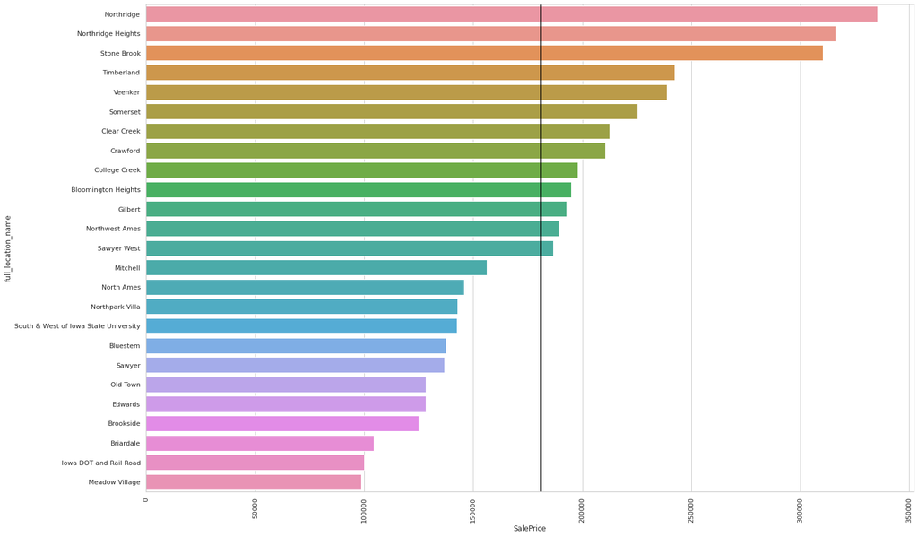

```python
ax = sns.barplot(y=df_mean.full_location_name, x=df_mean.SalePrice, data=df_mean)
sns.set(rc={'figure.figsize':(23,15)})
plt.xticks(rotation=90)
ax.axvline(df['SalePrice'].mean(), color="black", linewidth=3)
plt.show()
```

### 3.2 plot the sold year of the house versus the sale price

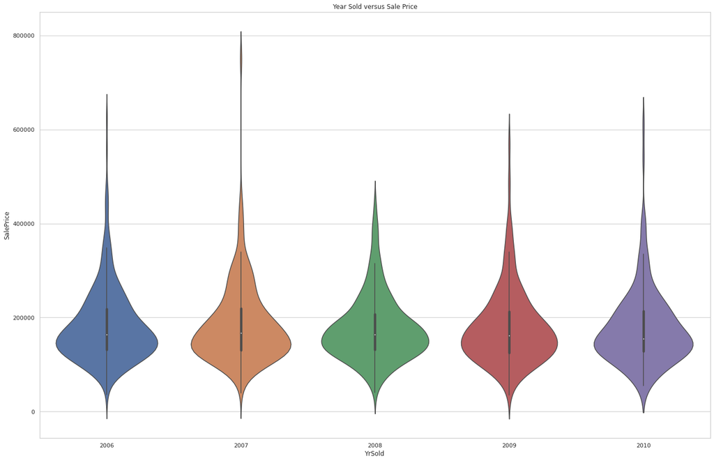

```python
sns.set(style="whitegrid")
plt.title('Year Sold versus Sale Price')
x = df.YrSold
y = df.SalePrice
ax = sns.violinplot(x, y)
plt.show()
```

### 3.3 plot the OverallCond and OverallQual regarding to the sale price

### There are ten levels for the overall quality and overall condition respectly. 1 means the worst and 10 means the best.

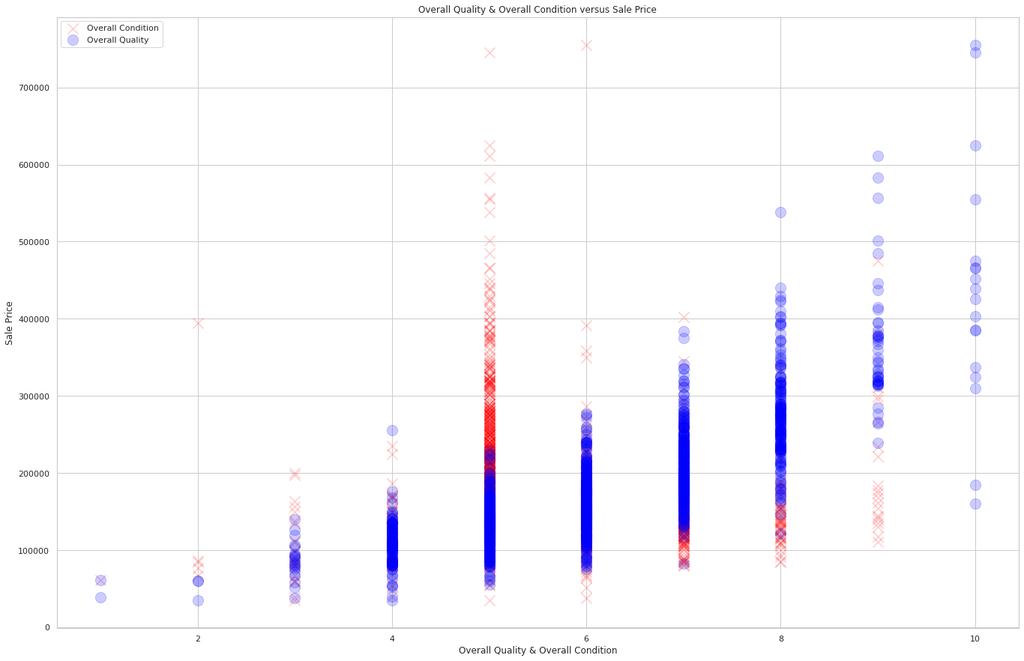

```python
cond = plt.scatter(df['OverallCond'],df['SalePrice'],marker='x',color='red',label='Overall Condition',alpha=0.2,s=200)
qual = plt.scatter(df['OverallQual'],df['SalePrice'],marker='o',color='blue',label='Overall Quality',alpha=0.2,s=200)
plt.title("Overall Quality & Overall Condition versus Sale Price")
plt.xlabel("Overall Quality & Overall Condition")
plt.ylabel("Sale Price")
plt.legend()
plt.show()
```

### 3.4 plot the "LotArea" in different locations versus the sale price

Lot size in square feet

```python
unique_loc_list = df['full_location_name'].unique().tolist()
```

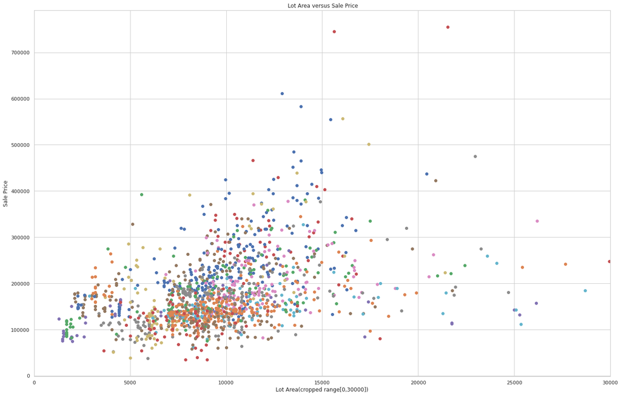

```python
for i in range(0,25):
    curr_df = df[df['full_location_name'] == unique_loc_list[i]]
    plt.scatter(curr_df["LotArea"], curr_df["SalePrice"]);
    # I crop the lot area range to [0,30000] since the data is highly concentrated in this subrange
    plt.xlim([0,30000])

    plt.title(' Lot Area versus Sale Price')
    plt.xlabel('Lot Area(cropped range[0,30000])')
    plt.ylabel('Sale Price')
plt.show()
```

### 3.5 plot the house style versus the sale price(blue bar: mean; red bar: median)

```
   1Story   One story
   1.5Fin   One and one-half story: 2nd level finished
   1.5Unf   One and one-half story: 2nd level unfinished
   2Story   Two story
   2.5Fin   Two and one-half story: 2nd level finished
   2.5Unf   Two and one-half story: 2nd level unfinished
   SFoyer   Split Foyer
   SLvl Split Level
```

[figure not shown]

```python
def subcategorybar(X, vals, width=0.8):
    n = len(vals)
    _X = np.arange(len(X))
    for i in range(n):
        plt.bar(_X - width/2. + i/float(n)*width, vals[i],
                width=width/float(n), align="edge")
    plt.xticks(_X, X)

x = df['HouseStyle'].unique()
y1 = df_mean_hs['SalePrice']
y2 = df_median_hs['SalePrice']

subcategorybar(x, [y1,y2])
plt.xlabel('HouseStyle')
plt.ylabel('SalePrice')
plt.title("HouseStyle versus SalePrice")
plt.show()
```

```
   Reg  Regular
   IR1  Slightly irregular
   IR2  Moderately Irregular
   IR3  Irregular
```

```python
df_mean_ls['SalePrice']
```

```
LotShape
IR1    206101.665289
IR2    239833.365854
IR3    216036.500000
Reg    164754.818378
Name: SalePrice, dtype: float64
```

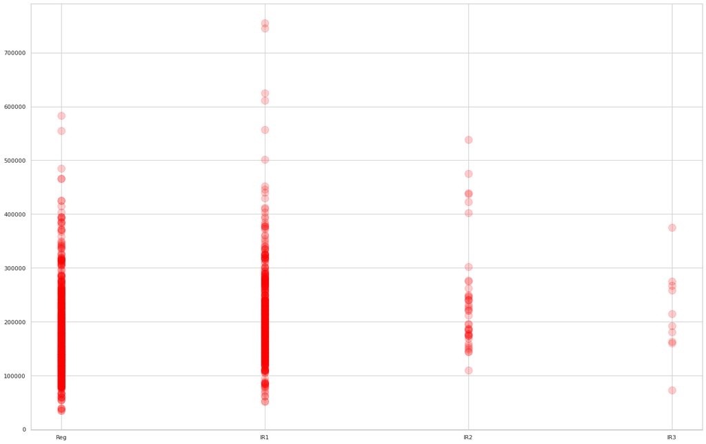

```python
shape = plt.scatter(df['LotShape'],df['SalePrice'],marker='o',color='red',label='Overall Condition',alpha=0.2,s=200)
```

## 4.Machine Learning

```python
from sklearn import model_selection
from sklearn import linear_model
```

### 4.1 Process data

### I drop 'Neighborhood', 'full_location_name', 'HouseStyle' and 'SaleCondition' since these features need one hot encoding. But there are too many different tags of a feature, so performing one hot encoding for them may cause sparse matrix(too many columns in my dataset). As a result, I decide to drop them. Then I will do one hot encoding for 'LotShape':'Reg', 'IR1', 'IR2', 'IR3' to maek them suitable for training model. Fianlly, I will get my prediction formula which is the purpose of this tutorial.

```python
# drop columns
ml_data = df.drop(['HouseStyle', 'Neighborhood','full_location_name','SaleCondition'], axis=1)
ml_data.head()
```

|  | SalePrice | LotArea | LotShape | OverallCond | OverallQual | YrSold |
| --- | --- | --- | --- | --- | --- | --- |
| 0 | 208500 | 8450 | Reg | 5 | 7 | 2008 |
| 1 | 181500 | 9600 | Reg | 8 | 6 | 2007 |
| 2 | 223500 | 11250 | IR1 | 5 | 7 | 2008 |
| 3 | 140000 | 9550 | IR1 | 5 | 7 | 2006 |
| 4 | 250000 | 14260 | IR1 | 5 | 8 | 2008 |

```python
# I will do one hot encoding for 'LotShape':'Reg', 'IR1', 'IR2', 'IR3'
ml_data['is_Reg']=df['LotShape'].apply(lambda x: 1 if x == 'Reg' else 0)
ml_data['is_IR1']=df['LotShape'].apply(lambda x: 1 if x == 'IR1' else 0)
ml_data['is_IR2']=df['LotShape'].apply(lambda x: 1 if x == 'IR2' else 0)
ml_data['is_IR3']=df['LotShape'].apply(lambda x: 1 if x == 'IR3' else 0)
ml_data = ml_data.drop(['LotShape'], axis=1)
```

```python
# re-assign the data for my training and testing
x = ml_data[['LotArea','OverallCond','OverallQual','YrSold','is_Reg','is_IR1','is_IR2','is_IR3']]
y= np.array(ml_data[['SalePrice']])

# split the data into training and testing sets
X_train, X_test, y_train, y_test = model_selection.train_test_split(x, y, test_size=0.2)
```

### 4.2 train model

```python
regr = linear_model.LinearRegression()
regr.fit(X_train,y_train)
```

```
LinearRegression()
```

### 4.3 test model accuracy

```python
regr.score(X_test,y_test)
```

```
0.7367454140257059
```

### My accuracy is not very outstanding. I think the reason may be there is not enough input for my training model since there are 81 columns in the dataset and what I inlcude in my input in only 8 of them.

### 4.4 predict

### Now I get the prection formula for predicting the sale price of house in Ames, Iowa. For example, I own a house in Ames and I am considering to sale it but I wanna know the sale price before I make my decision, like when to sale can get my favored price. So why not enter that house features into my formula and see the results. Below, I will use a example of features: 'LotArea': 10000, 'OverallCond': 8, 'OverallQual': 6, 'YrSold': 2021, 'is_Reg': 1, 'is_IR1': 0, 'is_IR2': 0, 'is_IR3': 0.

```python
predict_salePrice = regr.predict([[10000,8,6,2021,1,0,0,0]])
print("The sale price for this example is ", int(predict_salePrice), "$.")
```

```
The sale price for this example is  168921 $.
```

## 5.Conclusion

### It's very unlikely for a person to live in the same house forever. When deciding to change a house, everyone wants to sell a good price to make some money. So, a well estimation of the selling price of your house can make a big difeerence. The reuslts from the estimation formula can even influence your house buying decision, like the probability of rise of the house value. From those steps I did above, I can see a steady trend of sale price for houses in Ames city. But there is some difference of the price between different houses with various features. Like the houses located in Northbridge is expesive than those from other neighbourhood. And try to keep your house in a good condition and quality will contribute to selling a good price. This tuorial gives me a sense how data science can beneficial our lives for real. If I can include all of features from the original dataset to my training model, I believe the accuracy of my prediction will increase significantly.